# **Python vs. R** in Data Analysis

Iñaki Úcar

17 March, 2016

# Introduction

## Who

Iñaki Úcar

PhD Candidate & Teaching Assistant  
Dept. of Telematics Engineering  
Universidad Carlos III de Madrid

- http://www.it.uc3m.es/iucar
- http://www.enchufa2.es
- https://twitter.com/Enchufa2
- https://github.com/Enchufa2

## What (1)

[*Learning Seattle’s Work Habits from Bicycle Counts*](https://jakevdp.github.io/blog/2015/07/23/learning-seattles-work-habits-from-bicycle-counts/)  
**Pythonic Perambulations**  
Jake VanderPlas

[*Learning Seattle’s Work Habits from Bicycle Counts (with R!)*](https://rinzewind.org/blog-en/2015/learning-seattles-work-habits-from-bicycle-counts-with-r.html)  
**Will do stuff for stuff**  
José María Mateos (@Rinze)

## What (2)

Similarities and differences  
in a day-to-day analysis with Python and R

- Data Reading
- Data Cleaning
- Data Transforming
- Some Analysis…
- Data Visualisation

## Data Reading

```python
import pandas as pd
bikes = pd.read_csv('FremontBridge-14-02-2016.csv',
                    index_col='Date', parse_dates=True)
bikes.head()
```

```
##                      Fremont Bridge West Sidewalk  Fremont Bridge East Sidewalk
## Date
## 2012-10-03 00:00:00                           4.0                           9.0
## 2012-10-03 01:00:00                           4.0                           6.0
## 2012-10-03 02:00:00                           1.0                           1.0
## 2012-10-03 03:00:00                           2.0                           3.0
## 2012-10-03 04:00:00                           6.0                           1.0
```

## Data Cleaning

```python
bikes.columns = ['West', 'East']
bikes.fillna(0, inplace=True)
bikes['Total'] = bikes.eval('East + West')
bikes.head()
```

```
##                      West  East  Total
## Date
## 2012-10-03 00:00:00   4.0   9.0   13.0
## 2012-10-03 01:00:00   4.0   6.0   10.0
## 2012-10-03 02:00:00   1.0   1.0    2.0
## 2012-10-03 03:00:00   2.0   3.0    5.0
## 2012-10-03 04:00:00   6.0   1.0    7.0
```

## First Glance (1)

```python
weekly = bikes.resample('W').sum()
weekly.head()
```

```
##               West    East    Total
## Date
## 2012-10-07  7297.0  6995.0  14292.0
## 2012-10-14  8679.0  8116.0  16795.0
## 2012-10-21  7946.0  7563.0  15509.0
## 2012-10-28  6901.0  6536.0  13437.0
## 2012-11-04  6408.0  5786.0  12194.0
```

## First Glance (2)

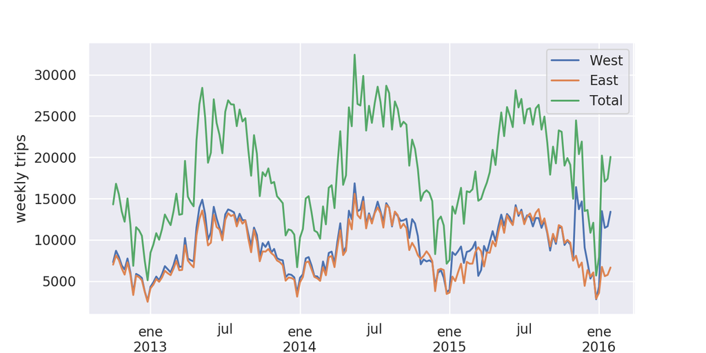

```python
import matplotlib.pyplot as plt
import seaborn; seaborn.set()  # plot styling
weekly.plot()
plt.ylabel('weekly trips')
```

## Data Transforming

```python
X = bikes.pivot_table(['East', 'West'], index=bikes.index.date,
                      columns=bikes.index.hour, fill_value=0)
X.head()
```

```
##            East                       ... West
## Date         0  1  2    3  4   5   6  ...   17   18  19  20  21  22  23
## 2012-10-03    9  6  1  3.0  1  10  50 ...  192  122  59  29  25  24   5
## 2012-10-04   11  0  6  3.0  1  11  51 ...  154  137  57  27  31  25  11
## 2012-10-05    7  4  3  2.0  2   7  37 ...  144  107  42  27  11  10  16
## 2012-10-06    7  5  2  2.0  1   2  15 ...  107   41  40  25  18  14  15
## 2012-10-07    5  5  1  2.0  2   3   8 ...  118   68  26  19  12   9   5
##
## [5 rows x 48 columns]
```

## PCA Analysis (1)

```python
from sklearn.decomposition import PCA
```

```python
Xpca = PCA(0.9).fit_transform(X.values)
Xpca.shape
```

```
## (1216, 3)
```

## PCA Analysis (2)

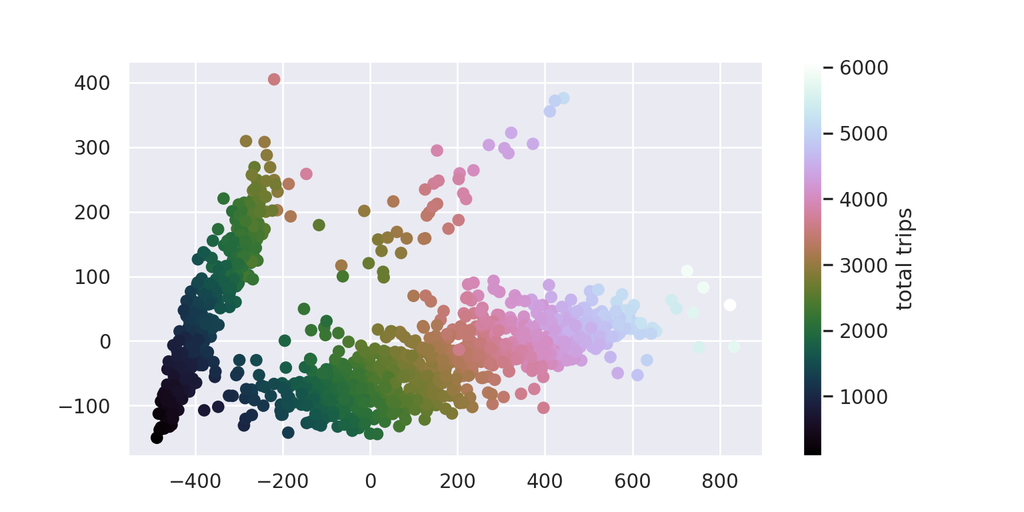

```python
total_trips = X.values.sum(1)
plt.scatter(Xpca[:, 0], Xpca[:, 1], c=total_trips, cmap='cubehelix')
plt.colorbar(label='total trips'); plt.show()
```

## Clustering

```python
from sklearn.mixture import GaussianMixture
gmm = GaussianMixture(3, covariance_type='full', random_state=0)
gmm.fit(Xpca)
```

```
## GaussianMixture(covariance_type='full', init_params='kmeans', max_iter=100,
##         means_init=None, n_components=3, n_init=1, precisions_init=None,
##         random_state=0, reg_covar=1e-06, tol=0.001, verbose=0,
##         verbose_interval=10, warm_start=False, weights_init=None)
```

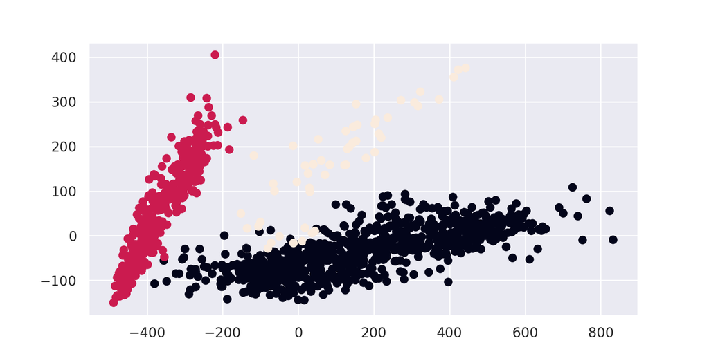

```python
cluster_label = gmm.predict(Xpca)
plt.scatter(Xpca[:, 0], Xpca[:, 1], c=cluster_label)
```

## Average Trend (1)

```python
X['Cluster'] = cluster_label
bikes = bikes.join(X['Cluster'], on=bikes.index.date)
by_hour = bikes.groupby(['Cluster', bikes.index.time]).mean()
by_hour.head()
```

```
##                       West      East      Total
## Cluster
## 0       00:00:00  5.318471  6.198726  11.517197
##         01:00:00  2.704459  2.950318   5.654777
##         02:00:00  2.235669  1.765605   4.001274
##         03:00:00  1.678981  1.408917   3.087898
##         04:00:00  4.285350  2.793631   7.078981
```

## Average Trend (2)

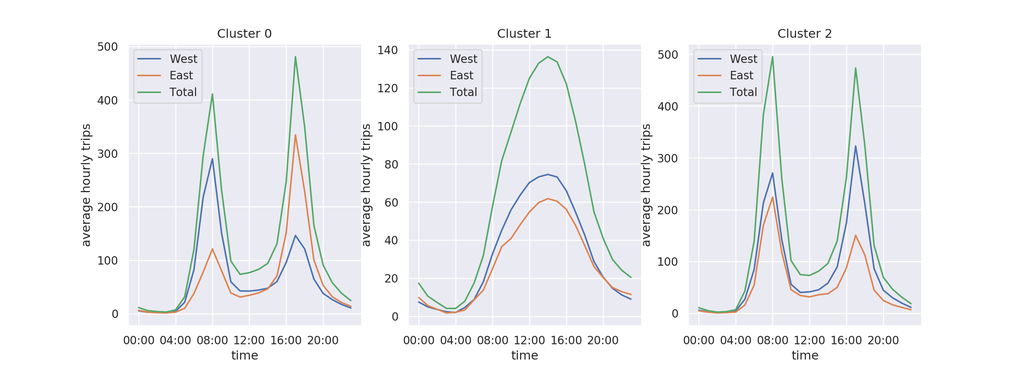

```python
import numpy as np
fig, ax = plt.subplots(1, 3, figsize=(14, 5))
hourly_ticks = 4 * 60 * 60 * np.arange(6)
for i in range(3):
    by_hour.ix[i].plot(ax=ax[i], xticks=hourly_ticks)
    ax[i].set_title('Cluster {0}'.format(i))
    ax[i].set_ylabel('average hourly trips')
```

## Seattle’s Work Habits

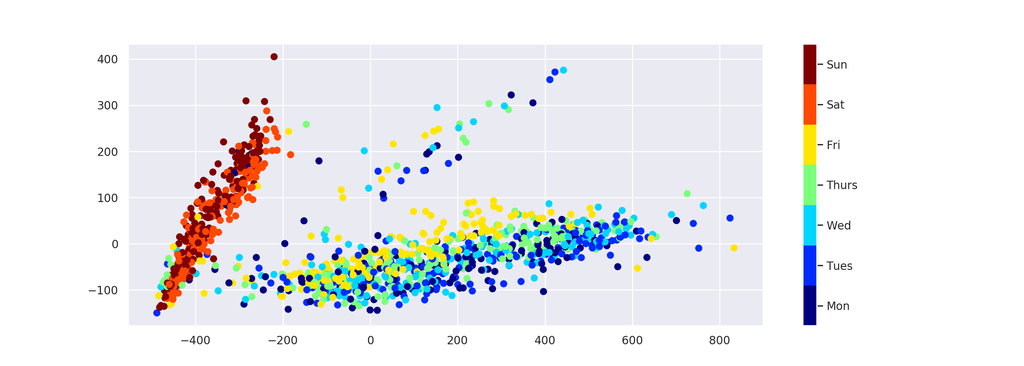

```python
dayofweek = pd.to_datetime(X.index).dayofweek
plt.scatter(Xpca[:, 0], Xpca[:, 1], c=dayofweek, cmap=plt.cm.get_cmap('jet', 7))
cb = plt.colorbar(ticks=range(7))
cb.set_ticklabels(['Mon', 'Tues', 'Wed', 'Thurs', 'Fri', 'Sat', 'Sun'])
plt.clim(-0.5, 6.5); plt.show()
```

## Data Reading

```r
bikes <- read.csv("FremontBridge-14-02-2016.csv")
head(bikes)
```

```
##                     Date Fremont.Bridge.West.Sidewalk
## 1 10/03/2012 12:00:00 AM                            4
## 2 10/03/2012 01:00:00 AM                            4
## 3 10/03/2012 02:00:00 AM                            1
## 4 10/03/2012 03:00:00 AM                            2
## 5 10/03/2012 04:00:00 AM                            6
## 6 10/03/2012 05:00:00 AM                           21
##   Fremont.Bridge.East.Sidewalk
## 1                            9
## 2                            6
## 3                            1
## 4                            3
## 5                            1
## 6                           10
```

## Data Cleaning

```r
bikes$Date <- as.POSIXct(bikes$Date, format="%m/%d/%Y %r")
names(bikes) <- c("Date", "West", "East")
bikes[is.na(bikes)] <- 0
bikes$Total <- with(bikes, West + East)
head(bikes)
```

```
##                  Date West East Total
## 1 2012-10-03 00:00:00    4    9    13
## 2 2012-10-03 01:00:00    4    6    10
## 3 2012-10-03 02:00:00    1    1     2
## 4 2012-10-03 03:00:00    2    3     5
## 5 2012-10-03 04:00:00    6    1     7
## 6 2012-10-03 05:00:00   21   10    31
```

## First Glance (1)

```r
library(dplyr); library(tidyr)
weekly <- bikes %>%
  gather(zone, count, -Date) %>%
  mutate(week=format(Date, format="%Y-%U")) %>%
  group_by(week, zone) %>%
  summarise(count=sum(count), Date=min(Date))
head(weekly)
```

```
## # A tibble: 6 x 4
## # Groups:   week [2]
##   week    zone  count Date
##   <chr>   <chr> <dbl> <dttm>
## 1 2012-40 East   6044 2012-10-03 00:00:00
## 2 2012-40 Total 12150 2012-10-03 00:00:00
## 3 2012-40 West   6106 2012-10-03 00:00:00
## 4 2012-41 East   8796 2012-10-07 00:00:00
## 5 2012-41 Total 18239 2012-10-07 00:00:00
## 6 2012-41 West   9443 2012-10-07 00:00:00
```

## First Glance (2)

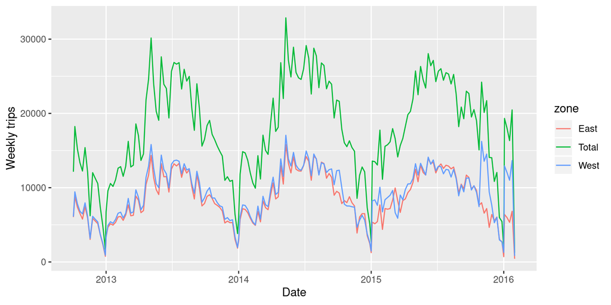

```r
library(ggplot2)
ggplot(weekly) + geom_line(aes(x=Date, y=count, color=zone)) +
  ylab("Weekly trips")
```

## Data Transforming

```r
bikes$hour <- strftime(bikes$Date, "%H")
bikes$Date2 <- as.Date(bikes$Date, tz="")
X <- bikes %>%
  gather(zone, count, East, West) %>%
  unite(zone_hour, zone, hour) %>%
  group_by(Date2, zone_hour) %>%
  summarise(count=sum(count)) %>%
  spread(zone_hour, count, fill=0)
head(X)
```

```
## # A tibble: 6 x 49
## # Groups:   Date2 [6]
##   Date2      East_00 East_01 East_02 East_03 East_04 East_05 East_06
##   <date>       <dbl>   <dbl>   <dbl>   <dbl>   <dbl>   <dbl>   <dbl>
## 1 2012-10-03       9       6       1       3       1      10      50
## 2 2012-10-04      11       0       6       3       1      11      51
## 3 2012-10-05       7       4       3       2       2       7      37
## 4 2012-10-06       7       5       2       2       1       2      15
## 5 2012-10-07       5       5       1       2       2       3       8
## 6 2012-10-08       5       2       0       4       2       7      48
## # … with 41 more variables: East_07 <dbl>, East_08 <dbl>, East_09 <dbl>,
## #   East_10 <dbl>, East_11 <dbl>, East_12 <dbl>, East_13 <dbl>,
## #   East_14 <dbl>, East_15 <dbl>, East_16 <dbl>, East_17 <dbl>,
## #   East_18 <dbl>, East_19 <dbl>, East_20 <dbl>, East_21 <dbl>,
## #   East_22 <dbl>, East_23 <dbl>, West_00 <dbl>, West_01 <dbl>,
## #   West_02 <dbl>, West_03 <dbl>, West_04 <dbl>, West_05 <dbl>,
## #   West_06 <dbl>, West_07 <dbl>, West_08 <dbl>, West_09 <dbl>,
## #   West_10 <dbl>, West_11 <dbl>, West_12 <dbl>, West_13 <dbl>,
## #   West_14 <dbl>, West_15 <dbl>, West_16 <dbl>, West_17 <dbl>,
## #   West_18 <dbl>, West_19 <dbl>, West_20 <dbl>, West_21 <dbl>,
## #   West_22 <dbl>, West_23 <dbl>
```

## PCA Analysis (1)

```r
pca1 <- prcomp(X[, -1])
cumvar <- cumsum(pca1$sdev^2 / sum(pca1$sdev^2))
cumvar[1:5]
```

```
## [1] 0,7963550 0,8655481 0,9190326 0,9428156 0,9539410
```

```r
Xpca <- as.data.frame(pca1$x[, 1:3])
names(Xpca) <- c("PC1", "PC2", "PC3")
Xpca$Date2 <- X$Date2
```

## PCA Analysis (2)

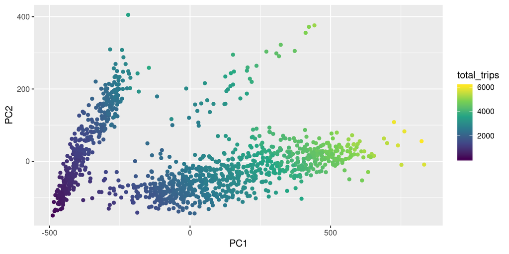

```r
Xpca$total_trips <- rowSums(X[, -1])
ggplot(Xpca) +
  geom_point(aes(x=PC1, y=PC2, color=total_trips)) +
  scale_colour_viridis_c()
```

## Clustering

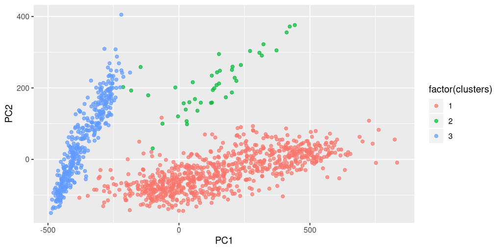

```r
library(mclust)
Xpca$clusters <- Mclust(Xpca[, c("PC1", "PC2", "PC3")], G=3,
                        prior=priorControl())$classification
ggplot(Xpca) +
  geom_point(aes(x=PC1, y=PC2, color=factor(clusters)), alpha=0.7)
```

## Average Trend (1)

```r
by_hour <- bikes %>%
  left_join(Xpca[, c("clusters", "Date2")], by="Date2") %>%
  group_by(hour, clusters) %>%
  summarise_at(vars(West, East, Total), mean) %>%
  gather(zone, count, -hour, -clusters)
by_hour$hour <- as.numeric(by_hour$hour)
head(by_hour)
```

```
## # A tibble: 6 x 4
## # Groups:   hour [2]
##    hour clusters zone  count
##   <dbl>    <dbl> <chr> <dbl>
## 1     0        1 West   5.36
## 2     0        2 West   5.93
## 3     0        3 West   7.44
## 4     1        1 West   2.70
## 5     1        2 West   3.26
## 6     1        3 West   4.89
```

## Average Trend (2)

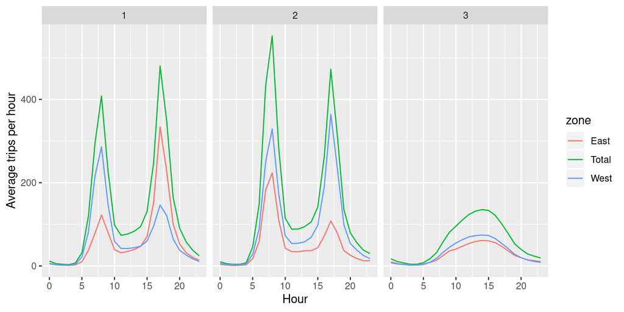

```r
ggplot(by_hour) +
  geom_line(aes(x=hour, y=count, group=zone, color=zone)) +
  facet_wrap(~ clusters) +
  xlab("Hour") + ylab("Average trips per hour")
```

## Seattle’s Work Habits

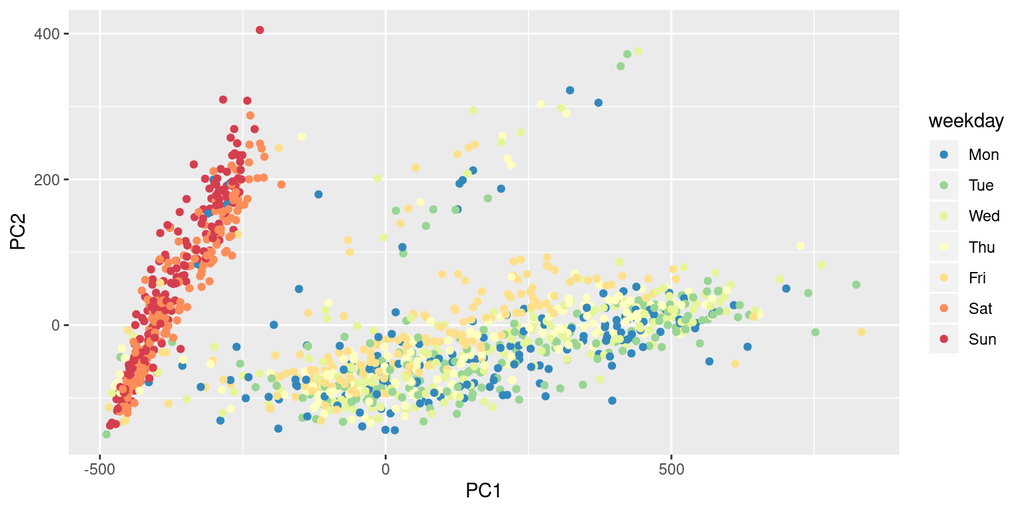

```r
Xpca$weekday <- Xpca$Date2 %>% weekdays(abbreviate=T) %>%
  factor(levels=c("Mon", "Tue", "Wed", "Thu", "Fri", "Sat", "Sun"))
ggplot(Xpca) +
  geom_point(aes(x=PC1, y=PC2, color=weekday)) +
  scale_color_brewer(palette="Spectral", direction=-1)
```

# Side Notes

## Data Reading

- Python
  - External library
  - OOP style
  - Built-in date parsing
  - Outstanding time series support
- R
  - Base R
  - Particular syntax
  - Time series are a PITA

## Data Cleaning

- R
  - **VERY** particular syntax:  
    `names(bikes) <- ...`
  - Data frame indexing
  - Column accessing

## First Glance (1)

- Python
  - `resample`!
- R
  - Pipes!
  - More work, but more **verbal**
  - Tidy data… beg your pardon?

## First Glance (2)

What is Tidy Data?

> Happy families are all alike; every unhappy family is unhappy in its own way  
> — Leo Tolstoy
- One variable per column
- **One observation per row**

Hadley Wickham. [**Tidy data**](http://vita.had.co.nz/papers/tidy-data.html). *The Journal of Statistical Software*, vol. 59, 2014.

## Data Transforming

- Python
  - `pivot_table`!
  - Groups of columns (zone, hour)
- R
  - Again, more work, but more **verbal**
  - Auxiliar columns

## PCA Analysis (1)

- Python
  - *Import then run* style
- R
  - *I know what I’m doing* style
  - … and let’s return to our beloved data frame

## PCA Analysis (2)

- Python
  - Nice default colors
- R
  - Inferred color bar

## Clustering

- Python
  - Define the object
  - Fit
  - Predict
- R
  - Mclust… done!

## Average Trend (1)

- Very similar
- Tidy vs. untidy data

## Average Trend (2)

- Python
  - `for` loop
- R
  - Faceting
  - Same scale by default

Thanks!

Python vs. & R, BigData Brothers